# Wine Quality

# Caso Final Módulo Estadística - Wine Quality

## Dataset

https://archive.ics.uci.edu/ml/datasets/wine+quality

### Descripción del Dataset

Esta base de datos, consta de dos conjuntos de datos relacionados con variantes rojas y blancas del vino portugués “Vinho Verde”.

### Variables del Dataset

**Variables de entrada**:  
* fixed acidity: cuantitativa.  
* volatile acidity: cuantitativa.  
* citric acid: cuantitativa.  
* residual sugar: cuantitativa.  
* chlorides: cuantitativa.  
* free sulfur dioxide: cuantitativa.  
* total sulfur dioxide: cuantitativa.  
* density: cuantitativa.  
* pH: cuantitativa.  
* sulphates: cuantitativa.  
* alcohol: cuantitativa.

**Variable de salida**:  
* quality (score between 0 and 10): cualitativa.

## Objetivo del caso práctico

Realizar un modelo de regresión lineal que permita representar la calidad (quality) del vino a través de las demás variables. Teniendo en cuenta cuáles de estas son más significativas.

## Solución del caso práctico

### Importar librerías

```r
library(tidyverse)
library(GGally)
```

```r
library(corrplot)
library(janitor)
```

### Lectura del dataset

Se leen los dos archivos correspondientes a vinos rojos y vinos blancos, para proceder a unirlos en un único dataframe que contenga todos los datos. Esto con el fin de tener más valores. Se utiliza también el método *clean_names()* para mejorar el nombre de las columnas del dataset.

```r
wine_quality <- read_delim('https://archive.ics.uci.edu/ml/machine-learning-databases/wine-quality/winequality-white.csv', delim = ';') %>%
  bind_rows(read_delim('https://archive.ics.uci.edu/ml/machine-learning-databases/wine-quality/winequality-red.csv', delim = ';')) %>%
  clean_names()
```

Se crea un dataframe con el mismo contenido anterior, pero transformando la calidad del vino a tipo factor.

```r
wine_quality_factor <- mutate(wine_quality, quality = factor(quality, ordered = TRUE))
```

### Análisis exploratorio

Primero se procede a generar una vista previa del dataset, utilizando el comando *glimpse*, que permite conocer la cantidad de columnas, filas, y el tipo de dato de cada una.

```r
glimpse(wine_quality)
```

```
## Rows: 6,497
## Columns: 12
## $ fixed_acidity        <dbl> 7.0, 6.3, 8.1, 7.2, 7.2, 8.1, 6.2, 7.0, 6.3, 8.1,…
## $ volatile_acidity     <dbl> 0.27, 0.30, 0.28, 0.23, 0.23, 0.28, 0.32, 0.27, 0…
## $ citric_acid          <dbl> 0.36, 0.34, 0.40, 0.32, 0.32, 0.40, 0.16, 0.36, 0…
## $ residual_sugar       <dbl> 20.70, 1.60, 6.90, 8.50, 8.50, 6.90, 7.00, 20.70,…
## $ chlorides            <dbl> 0.045, 0.049, 0.050, 0.058, 0.058, 0.050, 0.045, …
## $ free_sulfur_dioxide  <dbl> 45, 14, 30, 47, 47, 30, 30, 45, 14, 28, 11, 17, 1…
## $ total_sulfur_dioxide <dbl> 170, 132, 97, 186, 186, 97, 136, 170, 132, 129, 6…
## $ density              <dbl> 1.0010, 0.9940, 0.9951, 0.9956, 0.9956, 0.9951, 0…
## $ p_h                  <dbl> 3.00, 3.30, 3.26, 3.19, 3.19, 3.26, 3.18, 3.00, 3…
## $ sulphates            <dbl> 0.45, 0.49, 0.44, 0.40, 0.40, 0.44, 0.47, 0.45, 0…
## $ alcohol              <dbl> 8.8, 9.5, 10.1, 9.9, 9.9, 10.1, 9.6, 8.8, 9.5, 11…
## $ quality              <dbl> 6, 6, 6, 6, 6, 6, 6, 6, 6, 6, 5, 5, 5, 7, 5, 7, 6…
```

Como se observa con el comando anterior, todos los datos son de tipo double. Por esto, conviene ejecutar el comando *summary*, para así obtener un resumen estadístico del conjunto de datos.

```r
summary(wine_quality_factor)
```

```
##  fixed_acidity    volatile_acidity  citric_acid     residual_sugar
##  Min.   : 3.800   Min.   :0.0800   Min.   :0.0000   Min.   : 0.600
##  1st Qu.: 6.400   1st Qu.:0.2300   1st Qu.:0.2500   1st Qu.: 1.800
##  Median : 7.000   Median :0.2900   Median :0.3100   Median : 3.000
##  Mean   : 7.215   Mean   :0.3397   Mean   :0.3186   Mean   : 5.443
##  3rd Qu.: 7.700   3rd Qu.:0.4000   3rd Qu.:0.3900   3rd Qu.: 8.100
##  Max.   :15.900   Max.   :1.5800   Max.   :1.6600   Max.   :65.800
##
##    chlorides       free_sulfur_dioxide total_sulfur_dioxide    density
##  Min.   :0.00900   Min.   :  1.00      Min.   :  6.0        Min.   :0.9871
##  1st Qu.:0.03800   1st Qu.: 17.00      1st Qu.: 77.0        1st Qu.:0.9923
##  Median :0.04700   Median : 29.00      Median :118.0        Median :0.9949
##  Mean   :0.05603   Mean   : 30.53      Mean   :115.7        Mean   :0.9947
##  3rd Qu.:0.06500   3rd Qu.: 41.00      3rd Qu.:156.0        3rd Qu.:0.9970
##  Max.   :0.61100   Max.   :289.00      Max.   :440.0        Max.   :1.0390
##
##       p_h          sulphates         alcohol      quality
##  Min.   :2.720   Min.   :0.2200   Min.   : 8.00   3:  30
##  1st Qu.:3.110   1st Qu.:0.4300   1st Qu.: 9.50   4: 216
##  Median :3.210   Median :0.5100   Median :10.30   5:2138
##  Mean   :3.219   Mean   :0.5313   Mean   :10.49   6:2836
##  3rd Qu.:3.320   3rd Qu.:0.6000   3rd Qu.:11.30   7:1079
##  Max.   :4.010   Max.   :2.0000   Max.   :14.90   8: 193
##                                                   9:   5
```

Para conocer el comportamiento de las variables numéricas y su relación, se grafica una matriz de correlación:

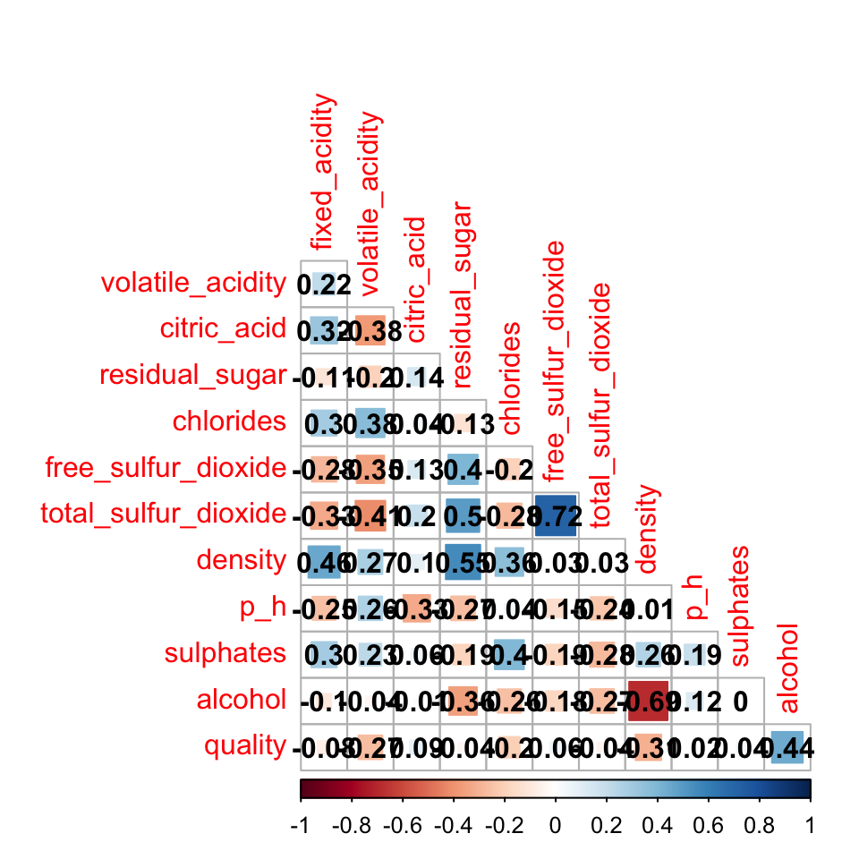

```r
corrplot(cor(wine_quality), method = 'square', type = 'lower', diag = FALSE, addCoef.col = 'black')
```

Para ver el comportamiento de las variables de forma gráfica entre sí, podemos crear una gráfica con *ggpairs*. Este método nos permitirá graficar cada variable con las demás para cuestiones de análisis.

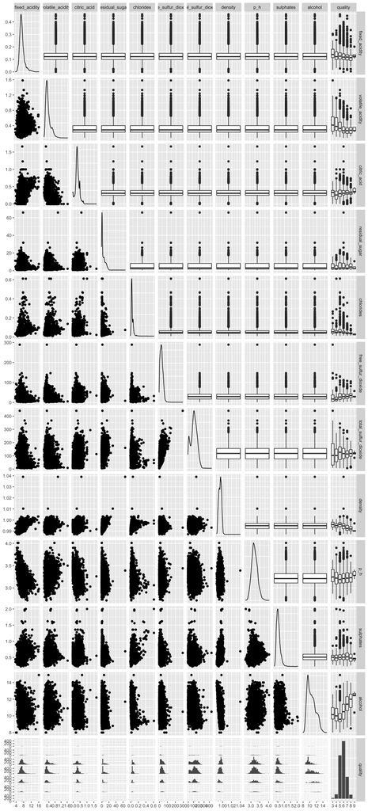

```r
ggpairs(wine_quality_factor, upper = list(continuous = 'box_no_facet'))
```

A través de las visualizaciones obtenidas anteriormente, podemos sacar algunas conclusiones:

- Las gráficas de densidad nos muestran que realmente no todas las variables siguen una distribución normal. Las que más se aproximan a una son: fixed_acidity, p_h, y quality.
- En términos generales, la calidad del vino es media. No existen vinos con calidades menores a 3, ni vinos con calidad perfecta de 10. Los valores se centran más que todo en calidades como 5, 6 y 7.
- El dataset contiene muchos valores que se podrían considerar outliers. Esto podría ser un factor que altere el modelo.
- No todas las variables se comportan de forma lineal. Las que poseen una mayor linealidad son: alcohol, p_h y total_sulfur_dioxide.

Se podría decir que el conjunto de datos es irregular, y que, aunque se vaya a realizar una regresión lineal, este modelo no podrá explicar realmente los datos. Por lo que muy probablemente el R2 sea bajo.

### Regresión Lineal

Se iniciará creando un modelo que utilice todas las variables del dataset para calcular la calidad del vino (quality), para así analizar si es posible mejorar el modelo.

```r
model <- lm(quality ~ ., data = wine_quality)
summary(model)
```

```
##
## Call:
## lm(formula = quality ~ ., data = wine_quality)
##
## Residuals:
##     Min      1Q  Median      3Q     Max
## -3.7569 -0.4597 -0.0412  0.4694  2.9907
##
## Coefficients:
##                        Estimate Std. Error t value Pr(>|t|)
## (Intercept)           5.576e+01  1.189e+01   4.688 2.81e-06 ***
## fixed_acidity         6.768e-02  1.557e-02   4.346 1.41e-05 ***
## volatile_acidity     -1.328e+00  7.737e-02 -17.162  < 2e-16 ***
## citric_acid          -1.097e-01  7.962e-02  -1.377    0.168
## residual_sugar        4.356e-02  5.156e-03   8.449  < 2e-16 ***
## chlorides            -4.837e-01  3.327e-01  -1.454    0.146
## free_sulfur_dioxide   5.970e-03  7.511e-04   7.948 2.22e-15 ***
## total_sulfur_dioxide -2.481e-03  2.767e-04  -8.969  < 2e-16 ***
## density              -5.497e+01  1.214e+01  -4.529 6.04e-06 ***
## p_h                   4.393e-01  9.037e-02   4.861 1.20e-06 ***
## sulphates             7.683e-01  7.612e-02  10.092  < 2e-16 ***
## alcohol               2.670e-01  1.673e-02  15.963  < 2e-16 ***
## ---
## Signif. codes:  0 '***' 0.001 '**' 0.01 '*' 0.05 '.' 0.1 ' ' 1
##
## Residual standard error: 0.7353 on 6485 degrees of freedom
## Multiple R-squared:  0.2921, Adjusted R-squared:  0.2909
## F-statistic: 243.3 on 11 and 6485 DF,  p-value: < 2.2e-16
```

Se puede observar que el R2 es bastante bajo, indicando que el modelo sólo explica aproximadamente un 29% de los datos. También, se puede observar que todas las variables se consideran significativas dentro del modelo, excepto citric_acid y chlorides.

Se procede a graficar el resultado de la regresión lineal.

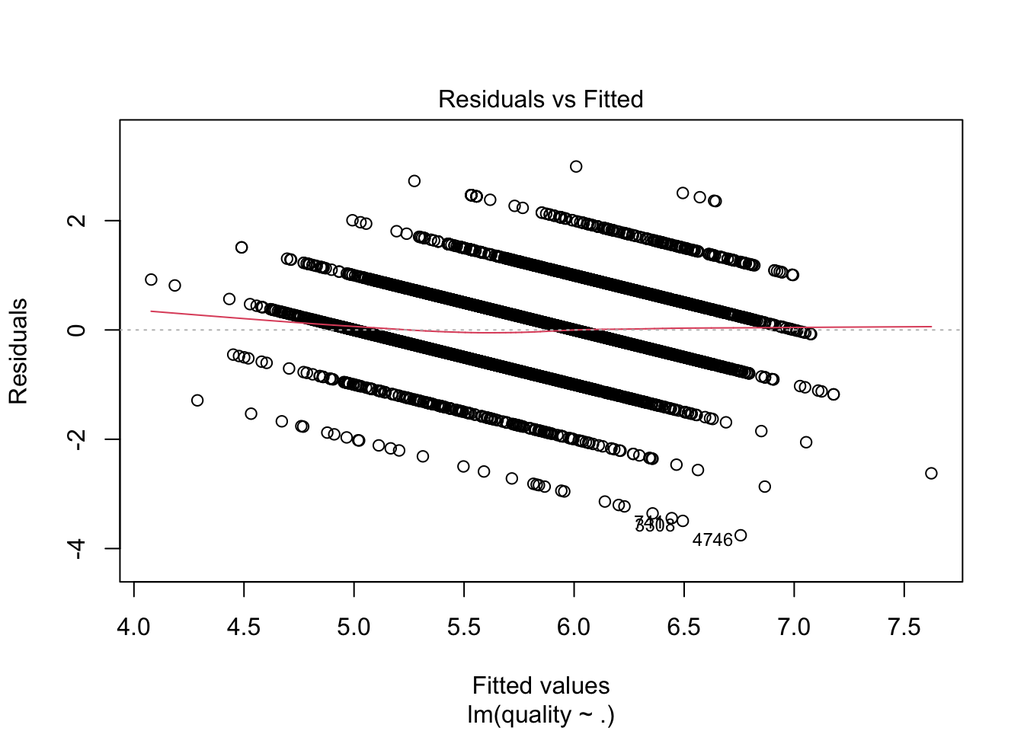

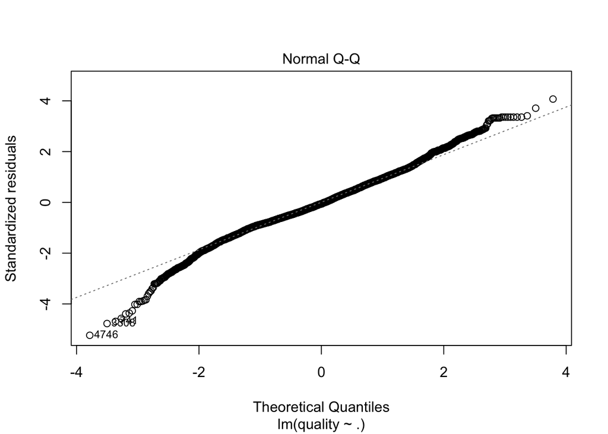

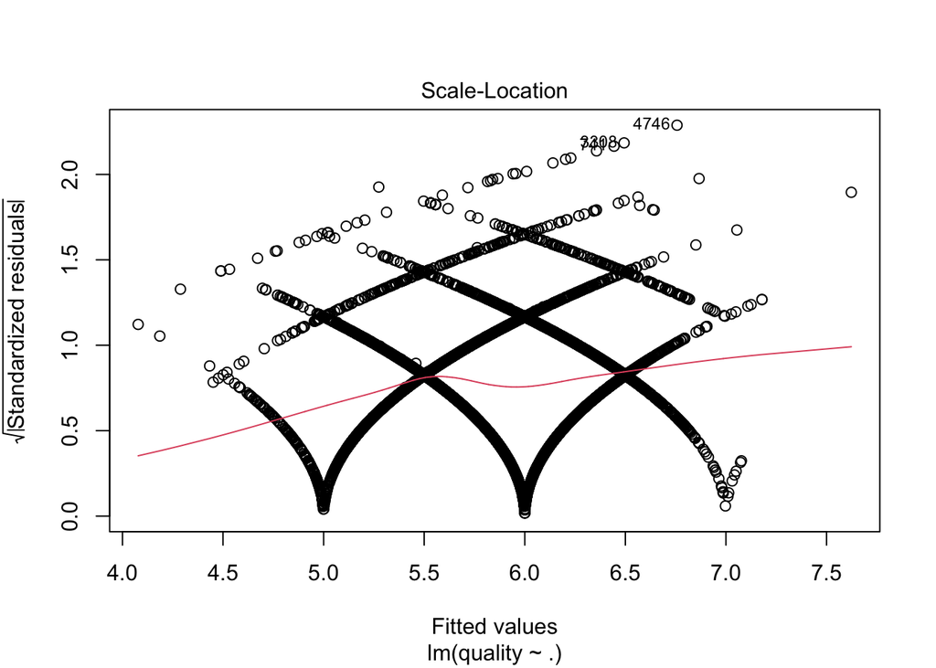

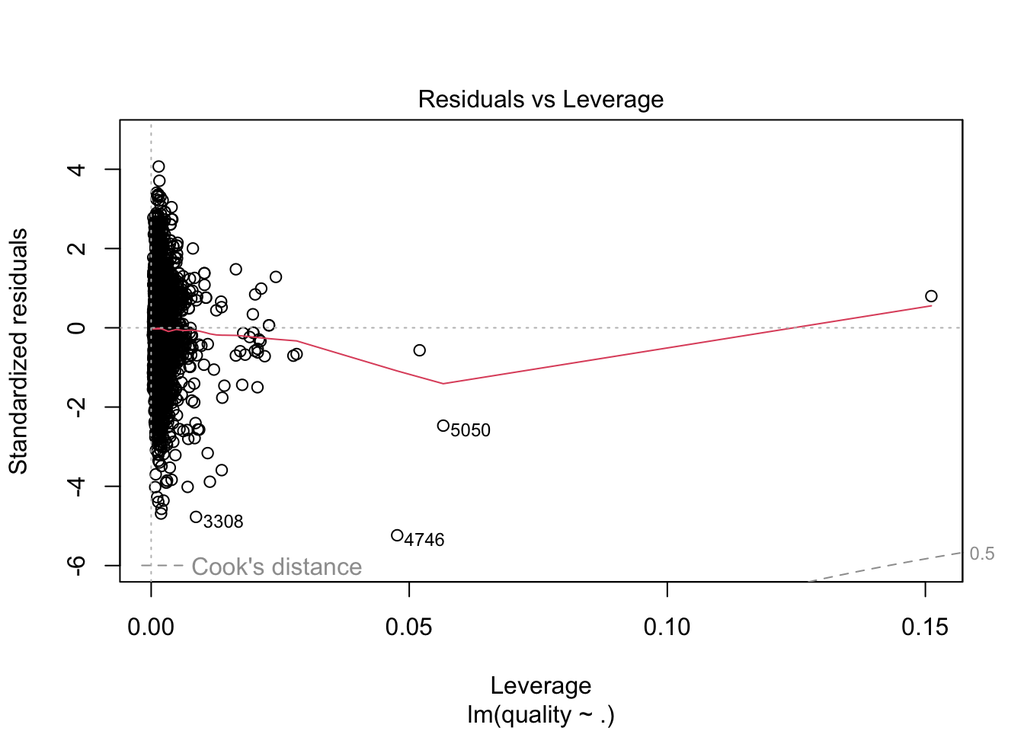

```r
plot(model)
```

A partir de los gráficos anteriores se puede decir:

- **Residuals vs Fitted (Residuos vs Valores Ajustados):** lo ideal sería poder visualizar puntos aleatorios a ambos lados del cero sin detectar un patrón. En este caso podemos ver patrones de líneas en los datos, por lo que se puede decir que el modelo calculados no es realmente apropiado para este conjunto de datos.
- **Normal QQ (Normalidad de los residuos):** idealmente, los residuos se deben distribuir aproximadamente alrededor de la línea de referencia sin patrones notables, esto sugiere que el modelo se ajusta adecuadamente a los datos y que los residuos siguen una distribución normal. En este caso se observan colas largas los extremos, esto indica que el modelo no es adecuado y que se necesitan ajustes.
- **Scale - Location (Escala - Ubicación):** La gráfica de escala-ubicación (scale-location) muestra si la varianza de los residuos es constante en diferentes niveles de la variable predictora. En la gráfica, si la varianza de los residuos es constante, los puntos deben estar distribuidos de manera uniforme alrededor de una línea horizontal. En este caso podemos observar patrones en los puntos, y la línea que representa la homocedasticidad, no es totalmente horizontal, lo que indica que la varianza de los errores no es constante a través de los datos. Es importante que exista homocedasticidad en los datos para que la regresión lineal tenga sentido, por eso se puede decir que el modelo no es adecuado.
- **Residuals vs Leverage (Residuales vs Influencia):** los puntos que se encuentran en la parte superior derecha o inferior derecha de la gráfica pueden ser puntos influyentes o atípicos (fuera de la línea de distancia de Cook). En general, la mayoría de los puntos caen dentro de la línea de distancia de Cook. Sin embargo, hay puntos que están muy alejados de los demás, por esto se deberían investigar para determinar si son valores atípicos o si realmente tiene que ver con el modelo.

Es decir, a partir de las gráficas anteriores y sus conclusiones, podemos afirmar que el modelo no es bueno para explicar los datos.

Se podrían eliminar del modelo aquellas variables no significativas para ver cómo influyen en el modelo:

```r
wine_quality_sig <- select(wine_quality, !c(chlorides, citric_acid))
model_sig <- lm(quality ~ ., data = wine_quality_sig)
summary(model_sig)
```

```
##
## Call:
## lm(formula = quality ~ ., data = wine_quality_sig)
##
## Residuals:
##     Min      1Q  Median      3Q     Max
## -3.7361 -0.4627 -0.0361  0.4649  2.9904
##
## Coefficients:
##                        Estimate Std. Error t value Pr(>|t|)
## (Intercept)           6.004e+01  1.165e+01   5.156 2.60e-07 ***
## fixed_acidity         6.621e-02  1.501e-02   4.412 1.04e-05 ***
## volatile_acidity     -1.304e+00  7.071e-02 -18.445  < 2e-16 ***
## residual_sugar        4.535e-02  5.025e-03   9.024  < 2e-16 ***
## free_sulfur_dioxide   5.934e-03  7.501e-04   7.911 2.98e-15 ***
## total_sulfur_dioxide -2.503e-03  2.716e-04  -9.217  < 2e-16 ***
## density              -5.942e+01  1.187e+01  -5.004 5.75e-07 ***
## p_h                   4.782e-01  8.838e-02   5.411 6.50e-08 ***
## sulphates             7.378e-01  7.451e-02   9.903  < 2e-16 ***
## alcohol               2.647e-01  1.666e-02  15.886  < 2e-16 ***
## ---
## Signif. codes:  0 '***' 0.001 '**' 0.01 '*' 0.05 '.' 0.1 ' ' 1
##
## Residual standard error: 0.7355 on 6487 degrees of freedom
## Multiple R-squared:  0.2916, Adjusted R-squared:  0.2906
## F-statistic: 296.7 on 9 and 6487 DF,  p-value: < 2.2e-16
```

Luego de realizar este nuevo modelo, podemos ver que el R2 realmente no cambia mucho. Incluso disminuye ligeramente. Por lo que, a pesar de todo, el modelo anterior sigue siendo algo mejor a comparación de este.

Se procede a utilizar el método *step* que usa el criterio de información de Akaike (AIC) para evaluar y comparar modelos de regresión con diferentes combinaciones de variables. De esta forma se intentará mejorar el modelo, tomando aquel con el AIC más bajo.

```r
model_step <- step(model, direction = 'backward')
```

```
## Start:  AIC=-3982.79
## quality ~ fixed_acidity + volatile_acidity + citric_acid + residual_sugar +
##     chlorides + free_sulfur_dioxide + total_sulfur_dioxide +
##     density + p_h + sulphates + alcohol
##
##                        Df Sum of Sq    RSS     AIC
## - citric_acid           1     1.026 3507.6 -3982.9
## <none>                              3506.5 -3982.8
## - chlorides             1     1.143 3507.7 -3982.7
## - fixed_acidity         1    10.214 3516.7 -3965.9
## - density               1    11.090 3517.6 -3964.3
## - p_h                   1    12.777 3519.3 -3961.2
## - free_sulfur_dioxide   1    34.155 3540.7 -3921.8
## - residual_sugar        1    38.595 3545.1 -3913.7
## - total_sulfur_dioxide  1    43.495 3550.0 -3904.7
## - sulphates             1    55.073 3561.6 -3883.5
## - alcohol               1   137.789 3644.3 -3734.4
## - volatile_acidity      1   159.265 3665.8 -3696.2
##
## Step:  AIC=-3982.89
## quality ~ fixed_acidity + volatile_acidity + residual_sugar +
##     chlorides + free_sulfur_dioxide + total_sulfur_dioxide +
##     density + p_h + sulphates + alcohol
##
##                        Df Sum of Sq    RSS     AIC
## <none>                              3507.6 -3982.9
## - chlorides             1     1.542 3509.1 -3982.0
## - fixed_acidity         1     9.265 3516.8 -3967.7
## - density               1    11.166 3518.7 -3964.2
## - p_h                   1    13.364 3520.9 -3960.2
## - free_sulfur_dioxide   1    34.505 3542.1 -3921.3
## - residual_sugar        1    38.337 3545.9 -3914.3
## - total_sulfur_dioxide  1    47.131 3554.7 -3898.2
## - sulphates             1    54.525 3562.1 -3884.7
## - alcohol               1   136.769 3644.3 -3736.4
## - volatile_acidity      1   175.494 3683.1 -3667.7
```

```r
summary(model_step)
```

```
##
## Call:
## lm(formula = quality ~ fixed_acidity + volatile_acidity + residual_sugar +
##     chlorides + free_sulfur_dioxide + total_sulfur_dioxide +
##     density + p_h + sulphates + alcohol, data = wine_quality)
##
## Residuals:
##     Min      1Q  Median      3Q     Max
## -3.7408 -0.4614 -0.0380  0.4712  2.9885
##
## Coefficients:
##                        Estimate Std. Error t value Pr(>|t|)
## (Intercept)           5.594e+01  1.189e+01   4.703 2.61e-06 ***
## fixed_acidity         6.270e-02  1.515e-02   4.139 3.53e-05 ***
## volatile_acidity     -1.287e+00  7.144e-02 -18.014  < 2e-16 ***
## residual_sugar        4.340e-02  5.155e-03   8.420  < 2e-16 ***
## chlorides            -5.550e-01  3.287e-01  -1.689   0.0913 .
## free_sulfur_dioxide   5.998e-03  7.509e-04   7.988 1.61e-15 ***
## total_sulfur_dioxide -2.546e-03  2.727e-04  -9.336  < 2e-16 ***
## density              -5.515e+01  1.214e+01  -4.544 5.62e-06 ***
## p_h                   4.481e-01  9.015e-02   4.971 6.83e-07 ***
## sulphates             7.637e-01  7.606e-02  10.041  < 2e-16 ***
## alcohol               2.649e-01  1.666e-02  15.903  < 2e-16 ***
## ---
## Signif. codes:  0 '***' 0.001 '**' 0.01 '*' 0.05 '.' 0.1 ' ' 1
##
## Residual standard error: 0.7354 on 6486 degrees of freedom
## Multiple R-squared:  0.2919, Adjusted R-squared:  0.2908
## F-statistic: 267.4 on 10 and 6486 DF,  p-value: < 2.2e-16
```

Por ende, la regresión lineal final sería:

```r
summary(lm(model_step))
```

```
##
## Call:
## lm(formula = model_step)
##
## Residuals:
##     Min      1Q  Median      3Q     Max
## -3.7408 -0.4614 -0.0380  0.4712  2.9885
##
## Coefficients:
##                        Estimate Std. Error t value Pr(>|t|)
## (Intercept)           5.594e+01  1.189e+01   4.703 2.61e-06 ***
## fixed_acidity         6.270e-02  1.515e-02   4.139 3.53e-05 ***
## volatile_acidity     -1.287e+00  7.144e-02 -18.014  < 2e-16 ***
## residual_sugar        4.340e-02  5.155e-03   8.420  < 2e-16 ***
## chlorides            -5.550e-01  3.287e-01  -1.689   0.0913 .
## free_sulfur_dioxide   5.998e-03  7.509e-04   7.988 1.61e-15 ***
## total_sulfur_dioxide -2.546e-03  2.727e-04  -9.336  < 2e-16 ***
## density              -5.515e+01  1.214e+01  -4.544 5.62e-06 ***
## p_h                   4.481e-01  9.015e-02   4.971 6.83e-07 ***
## sulphates             7.637e-01  7.606e-02  10.041  < 2e-16 ***
## alcohol               2.649e-01  1.666e-02  15.903  < 2e-16 ***
## ---
## Signif. codes:  0 '***' 0.001 '**' 0.01 '*' 0.05 '.' 0.1 ' ' 1
##
## Residual standard error: 0.7354 on 6486 degrees of freedom
## Multiple R-squared:  0.2919, Adjusted R-squared:  0.2908
## F-statistic: 267.4 on 10 and 6486 DF,  p-value: < 2.2e-16
```

## Conclusión

Aunque se ha obtenido una regresión lineal correcta, se puede decir que esta no explica el modelo realmente, ya que sólo lo hacce para el 29% de los datos. Esto puede deberse a diferentes factores como la normalidad o linealidad de los datos. Por lo que se recomendaría analizar estos datos a partir de otros modelos que se adapten mejor a estos.